# Naive Bayes Classifier

Ion Bueno Ulacia, NIA: 100364530

## a) Data Introduction

The dataset employed is The Stanford Sentiment Treebank, known as **SST-2** (https://nlp.stanford.edu/sentiment/) and it can be downloaded in https://gluebenchmark.com/tasks. The data is already split into training, validation and test sets, but as there are enough samples as training data, only this partition is used for the exercise. It is composed by movie reviews written in English.

This dataset is used in **sentiment analysis**, which means differentiating between positive and negative sentiments. It is one of the benchmarks of GLUE (General Language Understanding Evaluation).

The data is composed by sentences with a label indicating the corresponding sentiment, 1 for positive and 0 for negative. Mention that the original name of the columns, *sentence* and *label*, are renamed by *text* and *type* respectively.

First step is loading the data from the local store.

```r
setwd("~/UC3M/3º SEMI-TERM/Bayesian learning/Assignments/1. Naive Bayes Classifier")
sst2 <- read.csv(file = 'sst2.tsv', sep = '\t', header = TRUE)
dim(sst2)
```

```
## [1] 67349     2
```

As there are many samples, **67.349**, in order to avoid memory problems, the data is reduced to **8.000**.

```r
n_samples <- 8000
set.seed(123)
idx <- sample(seq_len(nrow(sst2)), size = n_samples)
sst2 <- sst2[idx, ]
dim(sst2)
```

```
## [1] 8000    2
```

It is important to check if there are enough samples of both classes.

```r
table(sst2$type)
```

```
##
##    0    1
## 3489 4511
```

The problem is still balanced.

## b) Type of Messages

As it has been commented before, the data is composed by two types of messages, positive and negative. The **positive** sentiment correspond with label or type **1**.

```r
sst2[(sst2$type == 1), 1][1:5]
```

```
## [1] ", and intelligent "
## [2] "the inspiration of the original "
## [3] "a movie that will stimulate hours of post viewing discussion , if only to be reminded of who did what to whom and why "
## [4] "of road movie , coming-of-age story and political satire "
## [5] "a marvel "
```

And the **negative** sentiment with label **0**.

```r
sst2[(sst2$type == 0), 1][1:5]
```

```
## [1] "sometimes inexpressive "
## [2] "exposes the limitations of his skill and the basic flaws in his vision . ' "
## [3] "'s plotless , shapeless "
## [4] "need a stronger stomach than us "
## [5] "'m afraid . "
```

## c) Data Cleaning

```r
library(tm)
```

The samples are stored in a corpus.

```r
corpus <- Corpus(VectorSource(sst2$text))
inspect(corpus[1:3])
```

```
## <<SimpleCorpus>>
## Metadata:  corpus specific: 1, document level (indexed): 0
## Content:  documents: 3
##
## [1] , and intelligent                sometimes inexpressive
## [3] the inspiration of the original
```

The preprocessing or cleaning data process consists on:

```r
clean_corpus <- tm_map(corpus, tolower)
clean_corpus <- tm_map(clean_corpus, removeNumbers)
clean_corpus <- tm_map(clean_corpus, removePunctuation)
clean_corpus <- tm_map(clean_corpus, removeWords,
                       stopwords("en"))
clean_corpus <- tm_map(clean_corpus, stripWhitespace)
```

## d) Wordclouds

First step is obtaining the indices for both classes.

```r
positive_indices <- which(sst2$type == 1)
negative_indices <- which(sst2$type == 0)
```

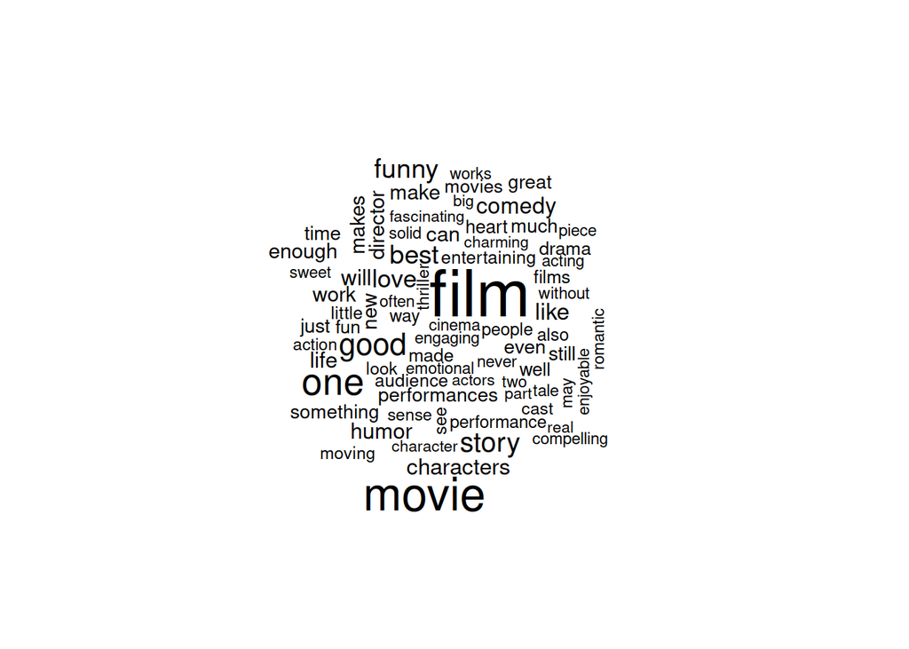

```r
library(wordcloud)
wordcloud(clean_corpus[positive_indices], min.freq=30, scale=c(3,.5))
```

As expected, there are some words related with a positive sentiment as *funny*, *best*, *good*, etc.

In next cell the sentences corresponding to the **negative** class are used.

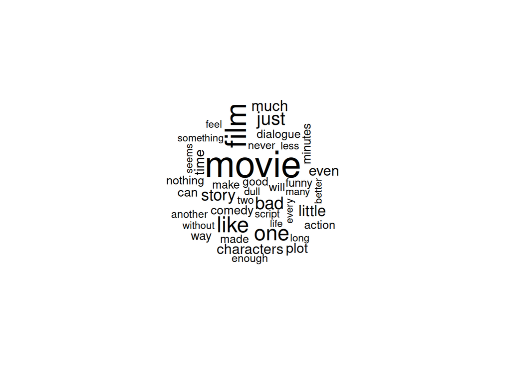

```r
wordcloud(clean_corpus[negative_indices], min.freq=30, scale=c(3,.5))
```

In this case we can see *bad* as a very frequent word, but there are not many more words related with a negative sentiment, unlike before.

Mention that in both cases the most common words are related with the movies vocabulary, as *movie*, *film* or *characters*, and there are not a lot of differences between the most frequent words in both wordclouds.

## e) Training and Test set

Next step is splitting the preprocessed data into training and test set. It is used 75% of the whole data as training and the rest for testing.

```r
smp_size <- floor(0.75 * nrow(sst2))
set.seed(123)
train_ind <- sample(seq_len(nrow(sst2)), size = smp_size)
sst2_train <- sst2[train_ind, ]
sst2_test <- sst2[-train_ind, ]
corpus_train <- clean_corpus[train_ind]
corpus_test <- clean_corpus[-train_ind]
```

Again, the balance between classes is checked in both sets.

```r
table(sst2_train$type)
```

```
##
##    0    1
## 2587 3413
```

```r
table(sst2_test$type)
```

```
##
##    0    1
##  902 1098
```

As it can be seen, there is no problem.

## f) Naive Bayes analysis

### Processing

To prepare the data for the classifier, it is created a sparse matrix data structure in which the rows of the matrix refer to document and the columns refer to words. The matrix is split according to the previous partition indexes.

```r
sst2_dtm <- DocumentTermMatrix(clean_corpus)
sst2_dtm_train <- sst2_dtm[train_ind, ]
sst2_dtm_test <- sst2_dtm[-train_ind, ]
```

Words which do not appear at least 5 times are removed, since it could be carry negative effects in the training of the classifier. Mention the counting is only in the training partition, while the words are removed in both sets.

```r
rep_times <- 5
rep_times_words <- findFreqTerms(sst2_dtm_train, rep_times)
length(rep_times_words)
```

```
## [1] 1378
```

```r
sst2_dtm_train <- DocumentTermMatrix(corpus_train,
                                    control=list(dictionary = rep_times_words))
sst2_dtm_test <- DocumentTermMatrix(corpus_test,
                                   control=list(dictionary = rep_times_words))
```

Naive Bayes classification needs present or absent info on each word in a message. For this reason next function is used to perform this encoding.

```r
convert_count <- function(x){
  y <- ifelse(x > 0, 1,0)
  y <- factor(y, levels=c(0,1), labels=c("No", "Yes"))
  return(y)
}
sst2_dtm_train <- apply(sst2_dtm_train, 2, convert_count)
sst2_dtm_test <- apply(sst2_dtm_test, 2, convert_count)
```

### Classifier

```r
library(e1071)
classifier <- naiveBayes(sst2_dtm_train, sst2_train$type)
```

## g) Results

After the training process, the classifier can make predictions over new sentences.

### Training

First step is looking into the performance respect the training data. For this purpose, the confusion matrix is shown in next cell.

```r
train_pred <- predict(classifier, newdata=sst2_dtm_train)
table(train_pred, sst2_train$type)
```

```
##
## train_pred    0    1
##          0 1714  396
##          1  873 3017
```

It is obtained an accuracy of **0.79**. As it is shown, the classifier struggles classifying the negative sentiment (label 0), with an accuracy of 0.66 respect the 0.88 obtained for the positive sentences.

### Test

Now, the predictions are over the test set.

```r
test_pred <- predict(classifier, newdata=sst2_dtm_test)
table(test_pred, sst2_test$type)
```

```
##
## test_pred   0   1
##         0 512 174
##         1 390 924
```

In this case, the accuracy is **0.72**. As it is normal, the value is smaller than with the training set, but they are close, so it is a sign the model generalizes well and there is not overfitting. In this case there is the same problem than with the training set respect the classification of the negative sentences. The classifier predicts better the positive sentences.

It could be a consequence of what has been commented in the negative sentiment wordcloud. Most of the frequent words which appear in the negative class are also common for the positive, whereas this one has many important words which are not common.

## h) Laplace smoothing

Now it is applied the Laplace smoothing.

```r
B.clas <- naiveBayes(sst2_dtm_train, sst2_train$type,laplace = 1)
B.preds <- predict(B.clas, newdata=sst2_dtm_test)
table(B.preds, sst2_test$type)
```

```
##
## B.preds   0   1
##       0 553 195
##       1 349 903
```

As expected the performance is slightly better, it is obtained **0.73** of accuracy, while before the value was **0.72**.

## i) Conclusions and possible improvements

As it has been commented before, the obtained accuracy in the test set is not very large, so it is likely not being the best model for this dataset, at least with the selected amount of samples. In spite of that, it is a considerable method, since it is simple and really fast compared with other models which can be applied in this problem, for example a recurrent neural network.

Some improvements could be applied in order to improve the performance of the classifier:

The Naive Bayes algorithm takes a lot of resources. For this reason, selecting the features of the message text in the practical application will reduce the dimension of the features vector space. This selection could be applied by means of correlation between words, so it avoids redundancy.